# Myco phosphoproteomics data normalisation

## Replacement of missing values

Selective replacement when there is only one or zero measurement for a site in a given condition (K, L, P).

Replacement with 1% quantile of all the conditions, to avoid a bias due to the increase in general intensity when the kinase is over-expressed.

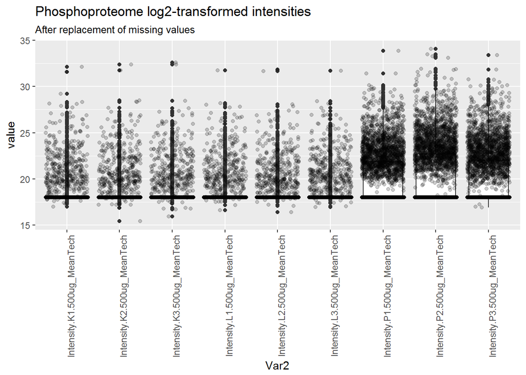

## t-test

Welch two-sided t-test followed by BH correction of the pvalue.

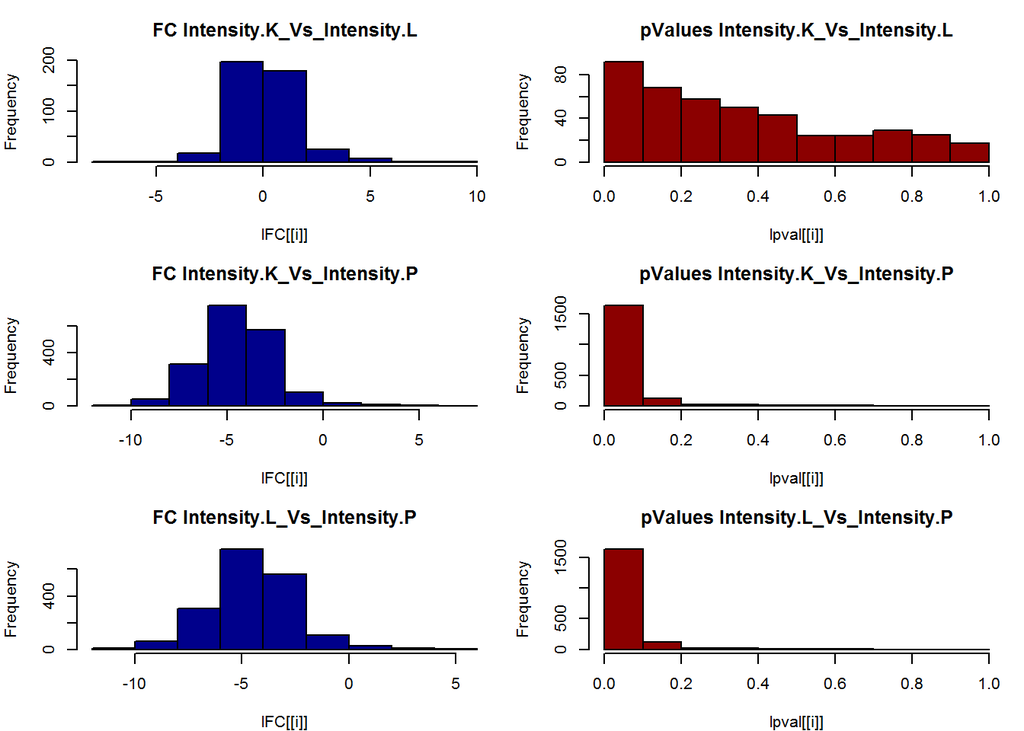

## Volcano plots

```
##
## FALSE  TRUE
##  2254     2
```

```
##
## FALSE  TRUE
##   872  1384
```

```
##
## FALSE  TRUE
##   870  1386
```

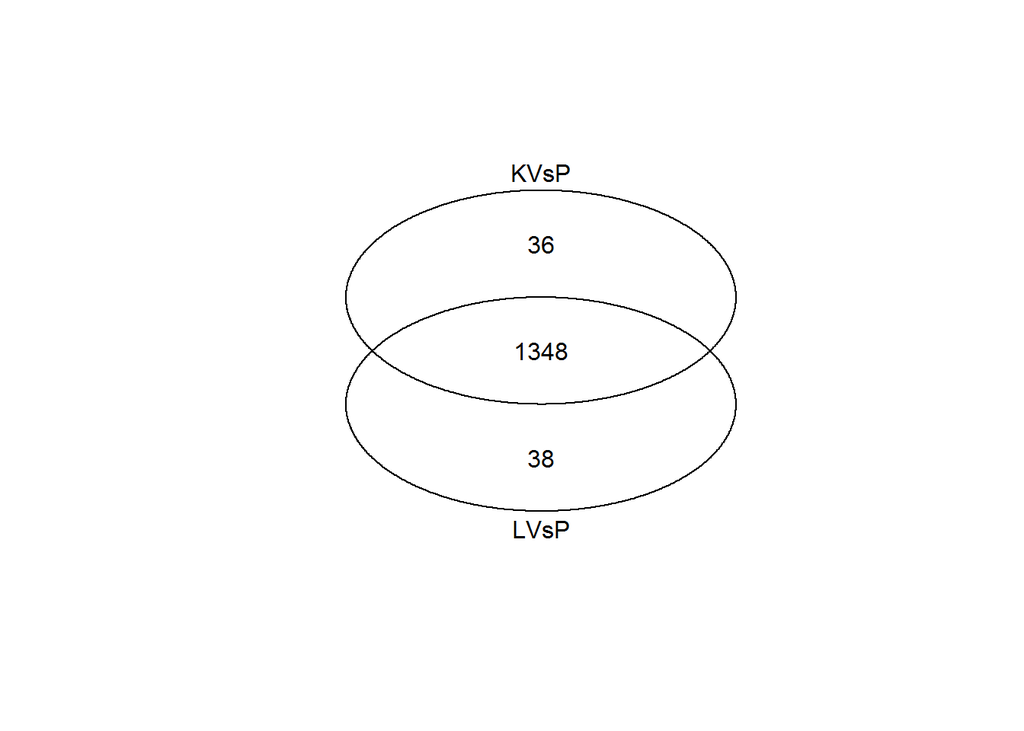

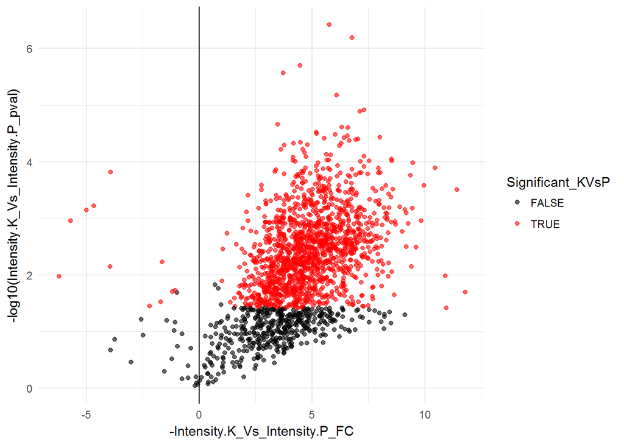

## Create phosID

Volcano with sites of interest:

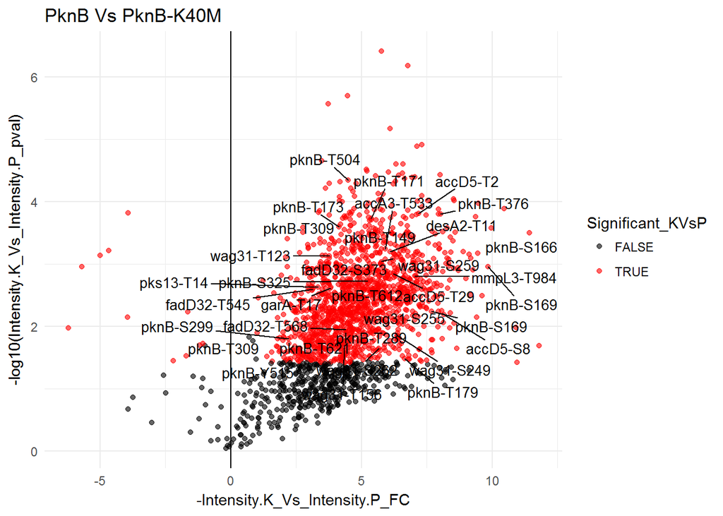

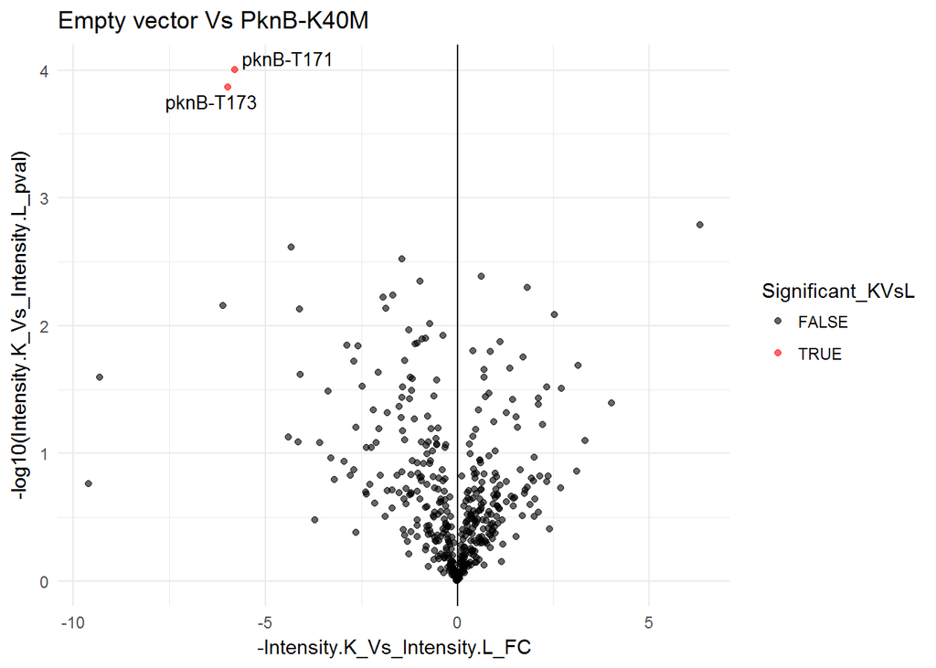

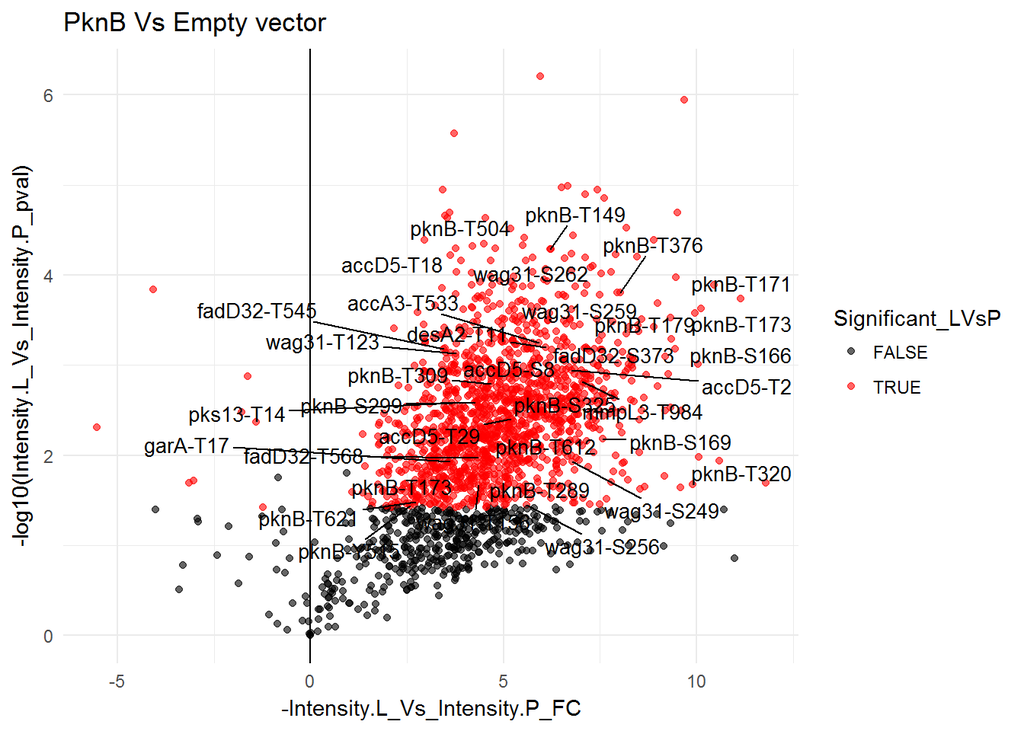

Volcano for the paper (with the known substrates of PknB):

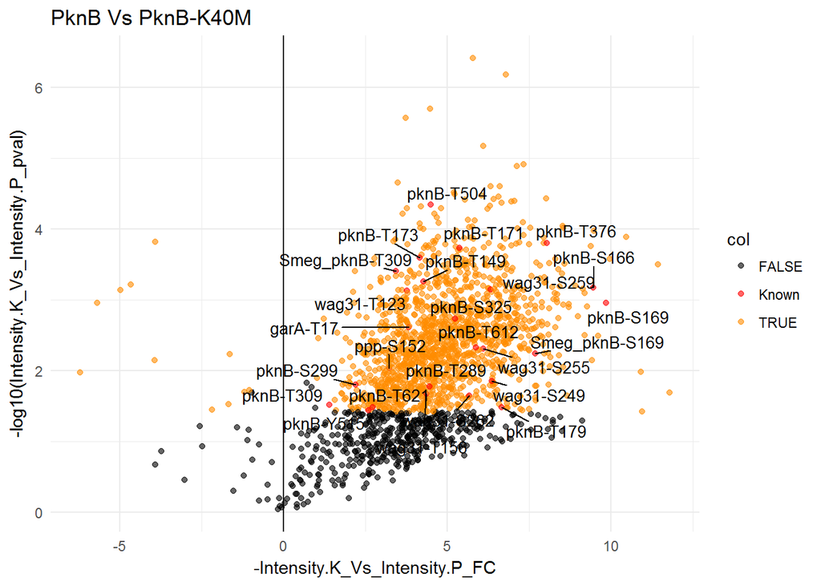

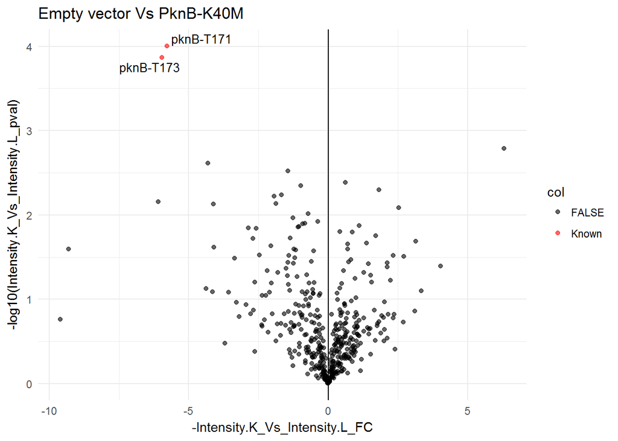

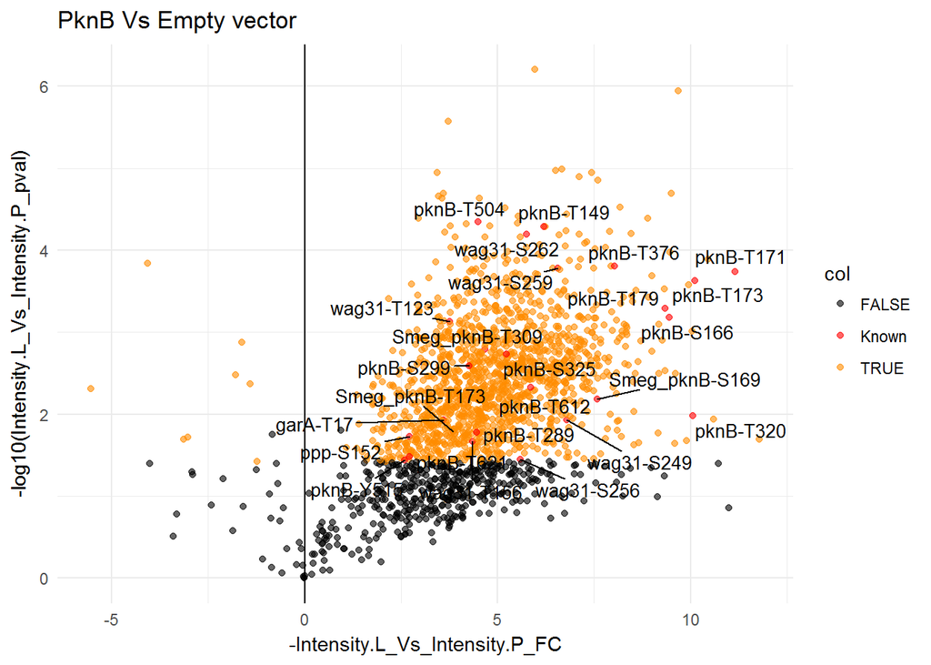